# STAT167 HW5 - Spring 2021

### (a) [5pt] Plot the USA map

First we load the USA map from `maps`.

```r
usa_map <- map_data("usa")
dim(usa_map)
## [1] 7243    6
glimpse(usa_map)
## Rows: 7,243
## Columns: 6
## $ long      <dbl> -101.4078, -101.3906, -101.3620, -101.3505, -101.3219, -1...
## $ lat       <dbl> 29.74224, 29.74224, 29.65056, 29.63911, 29.63338, 29.6448...
## $ group     <dbl> 1, 1, 1, 1, 1, 1, 1, 1, 1, 1, 1, 1, 1, 1, 1, 1, 1, 1, 1, ...
## $ order     <int> 1, 2, 3, 4, 5, 6, 7, 8, 9, 10, 11, 12, 13, 14, 15, 16, 17...
## $ region    <chr> "main", "main", "main", "main", "main", "main", "main", "...
## $ subregion <chr> NA, NA, NA, NA, NA, NA, NA, NA, NA, NA, NA, NA, NA, NA, N...
```

In the lecture, we have learned how to use `geom_polygon()` to make a simple black map (no line color, but with a black fill).

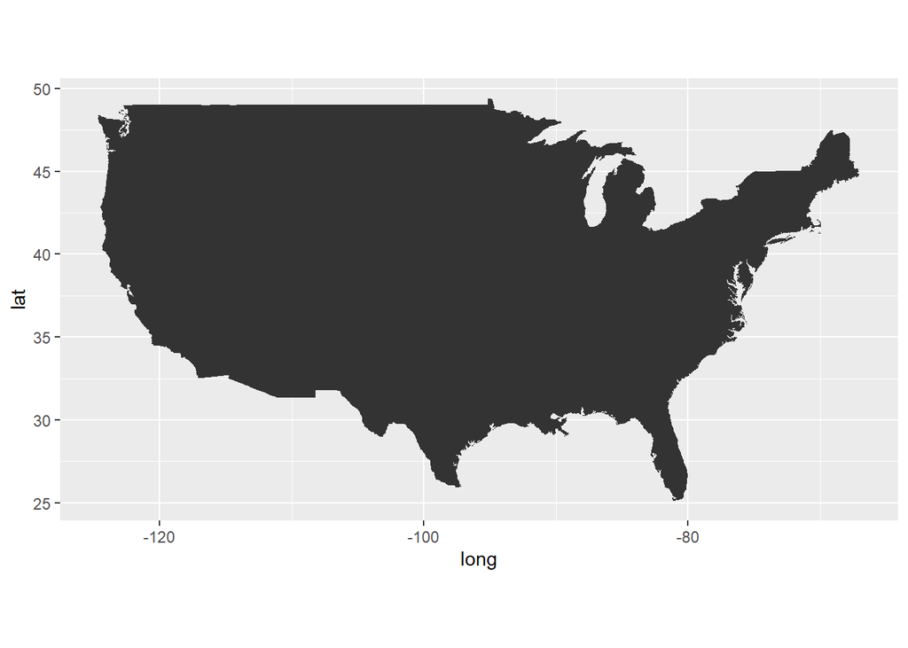

```r
ggplot(data = usa_map) +
  geom_polygon(aes(x = long, y = lat, group = group)) +
  coord_quickmap()
```

Google the coordinates of UCR, and then use `geom_point()` to mark the location of UCR on the USA map. In addition, change the outline/border color as well as the fill-in color of your map.

**ANSWER**

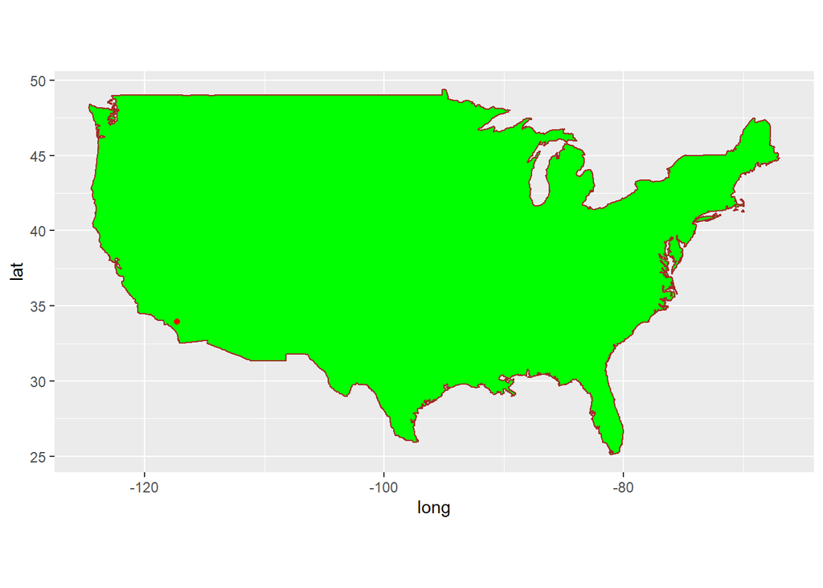

```r
# plot data by usa_map data by long, lat, group by group, fill color green and color brown then plot point of ucr coordinates
ggplot(data = usa_map) +
  geom_polygon(aes(x = long, y = lat, group = group), fill = "green", color = "brown") +
  coord_quickmap() +
  geom_point( mapping = aes(x = -117.33, y = 33.97), color = "red")
```

### (b) [15pt] Plot the states map

In addition to `geom_polygon()`, we can use `geom_map()` to draw maps too. Basically, `geom_map()` acts as a wrapper of `geom_polygon()`. See more details in the `geom_map()` documentation @ http://ggplot2.tidyverse.org/reference/geom_map.html

Here is the example code of a states map from the lecture. We can plot all the states, map the `fill` aesthetic to `region` and set the the lines of state borders to white color.

```r
states_map <- map_data("state")
dim(states_map)
## [1] 15537     6
glimpse(states_map)
## Rows: 15,537
## Columns: 6
## $ long      <dbl> -87.46201, -87.48493, -87.52503, -87.53076, -87.57087, -8...
## $ lat       <dbl> 30.38968, 30.37249, 30.37249, 30.33239, 30.32665, 30.3266...
## $ group     <dbl> 1, 1, 1, 1, 1, 1, 1, 1, 1, 1, 1, 1, 1, 1, 1, 1, 1, 1, 1, ...
## $ order     <int> 1, 2, 3, 4, 5, 6, 7, 8, 9, 10, 11, 12, 13, 14, 15, 16, 17...
## $ region    <chr> "alabama", "alabama", "alabama", "alabama", "alabama", "a...
## $ subregion <chr> NA, NA, NA, NA, NA, NA, NA, NA, NA, NA, NA, NA, NA, NA, N...
```

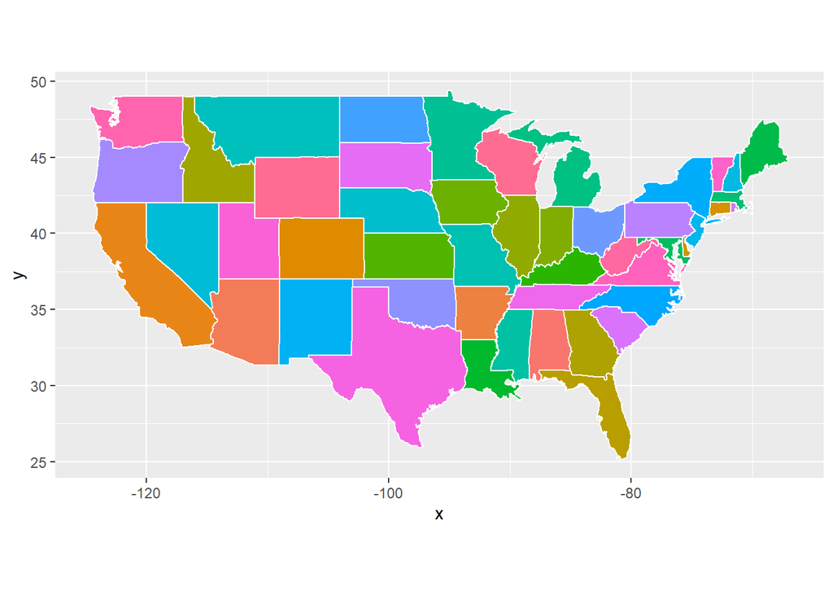

```r
ggplot() +
  geom_map(data = states_map, map = states_map,
           aes(map_id = region, fill = region), color="white") +
  # geom_map() doesn't work in such a way that ggplot2 knows the extend of the map values, so you always have to expand the limits by hand yourself.
  expand_limits(x = states_map$long, y = states_map$lat) +
  coord_quickmap() +
  guides(fill = FALSE) # do this to leave off the color legend
```

Next, we will use the built-in `state` data sets in R to annotate our states map. In particular, `state.x77` is a two-dimensional array containing 8 variables and data from all 50 states.

```r
#?state.x77
head(state.x77)
##            Population Income Illiteracy Life Exp Murder HS Grad Frost   Area
## Alabama          3615   3624        2.1    69.05   15.1    41.3    20  50708
## Alaska            365   6315        1.5    69.31   11.3    66.7   152 566432
## Arizona          2212   4530        1.8    70.55    7.8    58.1    15 113417
## Arkansas         2110   3378        1.9    70.66   10.1    39.9    65  51945
## California      21198   5114        1.1    71.71   10.3    62.6    20 156361
## Colorado         2541   4884        0.7    72.06    6.8    63.9   166 103766

state_data <- as.data.frame(state.x77)
state_data$State <- tolower(rownames(state_data))
state_data %>% glimpse()
## Rows: 50
## Columns: 9
## $ Population <dbl> 3615, 365, 2212, 2110, 21198, 2541, 3100, 579, 8277, 493...
## $ Income     <dbl> 3624, 6315, 4530, 3378, 5114, 4884, 5348, 4809, 4815, 40...
## $ Illiteracy <dbl> 2.1, 1.5, 1.8, 1.9, 1.1, 0.7, 1.1, 0.9, 1.3, 2.0, 1.9, 0...
## $ `Life Exp` <dbl> 69.05, 69.31, 70.55, 70.66, 71.71, 72.06, 72.48, 70.06, ...
## $ Murder     <dbl> 15.1, 11.3, 7.8, 10.1, 10.3, 6.8, 3.1, 6.2, 10.7, 13.9, ...
## $ `HS Grad`  <dbl> 41.3, 66.7, 58.1, 39.9, 62.6, 63.9, 56.0, 54.6, 52.6, 40...
## $ Frost      <dbl> 20, 152, 15, 65, 20, 166, 139, 103, 11, 60, 0, 126, 127,...
## $ Area       <dbl> 50708, 566432, 113417, 51945, 156361, 103766, 4862, 1982...
## $ State      <chr> "alabama", "alaska", "arizona", "arkansas", "california"...
```

Below is the example code from the lecture for a state population map. We first create an aesthetic mapping for `map_id` to the column `State` (state names in lower case) in the `state_data` data frame. We then call `geom_map` again and map the `fill` aesthetic to the `Population` variable in `state_data`.

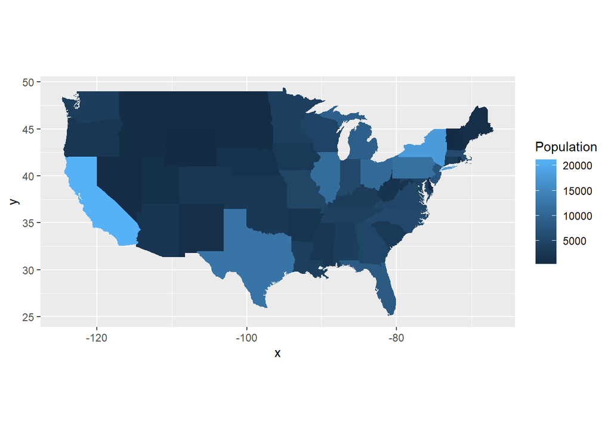

```r
ggplot(data = state_data, aes(map_id = State))+
  geom_map(map = states_map,
           aes(fill = Population)) +
  expand_limits(x = states_map$long, y = states_map$lat) +
  coord_quickmap()
```

#### (i) [5pt] Draw your own states map and map the `fill` aesthetic to `Income` in the `state.x77` data set

**ANSWER**

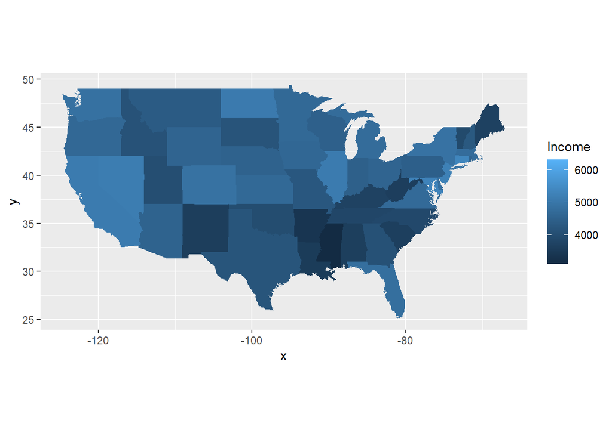

```r
# plot map of us states and fill by income
ggplot(data = state_data, aes(map_id = State))+
  geom_map(map = states_map,
           aes(fill = Income)) +
  expand_limits(x = states_map$long, y = states_map$lat) +
  coord_quickmap()
```

#### (ii) [10pt] Add 50 colorful points to your map

```r
head(state.center)
## $x
##  [1]  -86.7509 -127.2500 -111.6250  -92.2992 -119.7730 -105.5130  -72.3573
##  [8]  -74.9841  -81.6850  -83.3736 -126.2500 -113.9300  -89.3776  -86.0808
## [15]  -93.3714  -98.1156  -84.7674  -92.2724  -68.9801  -76.6459  -71.5800
## [22]  -84.6870  -94.6043  -89.8065  -92.5137 -109.3200  -99.5898 -116.8510
## [29]  -71.3924  -74.2336 -105.9420  -75.1449  -78.4686 -100.0990  -82.5963
## [36]  -97.1239 -120.0680  -77.4500  -71.1244  -80.5056  -99.7238  -86.4560
## [43]  -98.7857 -111.3300  -72.5450  -78.2005 -119.7460  -80.6665  -89.9941
## [50] -107.2560
##
## $y
##  [1] 32.5901 49.2500 34.2192 34.7336 36.5341 38.6777 41.5928 38.6777 27.8744
## [10] 32.3329 31.7500 43.5648 40.0495 40.0495 41.9358 38.4204 37.3915 30.6181
## [19] 45.6226 39.2778 42.3645 43.1361 46.3943 32.6758 38.3347 46.8230 41.3356
## [28] 39.1063 43.3934 39.9637 34.4764 43.1361 35.4195 47.2517 40.2210 35.5053
## [37] 43.9078 40.9069 41.5928 33.6190 44.3365 35.6767 31.3897 39.1063 44.2508
## [46] 37.5630 47.4231 38.4204 44.5937 43.0504
head(state.region)
## [1] South West  West  South West  West
## Levels: Northeast South North Central West
```

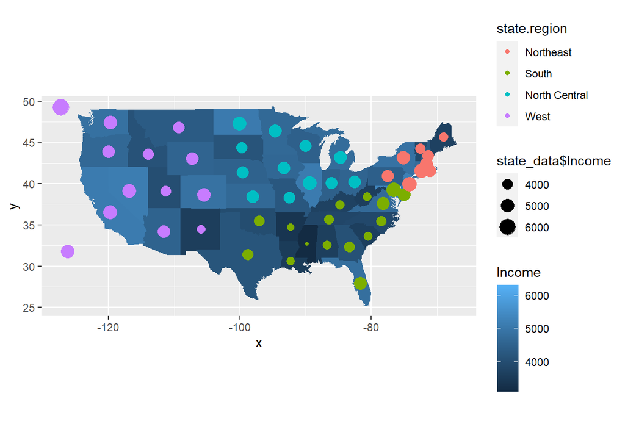

```r
# turn it into a data frame
state_centers <- as.data.frame(state.center)
# plot data with x = x and y = y color by region and size by income
ggplot(data = state_data, aes(map_id = State))+
  geom_map(map = states_map,
           aes(fill = Income)) +
  expand_limits(x = states_map$long, y = states_map$lat) +
  geom_point(aes(x = state_centers$x, y = state_centers$y, color = state.region, size = state_data$Income)) +
  coord_quickmap()
```